# The Impact of COVID-19 on Petroleum Consumption by the Industrial Sector in the US

Timeseries Analysis

Author

Koki Taniguchi

## 1 Introduction

This research investigates the impact of the COVID-19 pandemic on petroleum consumption in the industrial sector in the U.S. The pandemic resulted in significant alterations in global energy demand, leading to shifts in petroleum usage patterns driven by lockdowns, mobility restrictions, and changes in work and lifestyle habits. Understanding these impacts is crucial for several reasons. The industrial sector faced disruptions in production that altered its energy needs. This shifts not only influence short-term energy demand but also have long-term implications for energy policy, economic recovery, and sustainability planning.

The analysis will be conducted through multiple stages, beginning with data acquisition and cleaning from the U.S. Energy Information Administration (EIA). Following this, we will explore the time series data and preprocess it to prepare for analysis. Subsequently, ARIMA modeling, along with Auto-ETS and Auto-ARIMA models, will be applied to determine the best forecasting model for petroleum consumption. The final stage will involve a comparative analysis of the forecasted values against actual data during the COVID-19 period.

Understanding the shifts in energy consumption caused by COVID-19 is essential as it provides insights into the resilience and adaptability of different sectors to sudden economic shocks. Additionally, analyzing the pandemic’s effects on energy consumption is vital for shaping energy policy and planning. By identifying how this sector responded to the crisis, policymakers and energy providers can develop effective strategies for managing future disruptions, ensuring energy security, and supporting a transition toward more sustainable energy systems. Furthermore, comprehending the economic implications of these shifts is crucial for informing post-pandemic recovery strategies that promote efficient energy use while fostering economic growth.

## 2 Data Cleaning

### 2.1 Libraries

```r
library(fpp2)
library(tidyverse)
library(forecast)
library(readxl)
library(openxlsx)
```

### 2.2 Import Data

```r
# Import Data
data_industrial <- read_csv("data/MER_T03_07B.csv")%>%
  mutate(Description = as.factor(Description))
```

### 2.3 Data Cleaning

```r
# Check the Description to filter
levels(data_industrial$Description) # "Total Petroleum Consumed by the Industrial Sector"
```

```
 [1] "Asphalt and Road Oil Consumed by the Industrial Sector"
 [2] "Distillate Fuel Oil Consumed by the Industrial Sector"
 [3] "Kerosene Consumed by the Industrial Sector"
 [4] "Lubricants Consumed by the Industrial Sector"
 [5] "Motor Gasoline Consumed by the Industrial Sector"
 [6] "Other Petroleum Products Consumed by the Industrial Sector"
 [7] "Petroleum Coke Consumed by the Industrial Sector"
 [8] "Propane Consumed by the Industrial Sector"
 [9] "Propane/Propylene Consumed by the Industrial Sector"
[10] "Propylene Consumed by the Industrial Sector"
[11] "Residual Fuel Oil Consumed by the Industrial Sector"
[12] "Total Hydrocarbon Gas Liquids Consumed by the Industrial Sector"
[13] "Total Petroleum Consumed by the Industrial Sector"
```

```r
# Data Cleaning
industrial <- data_industrial %>%
  filter(Description == "Total Petroleum Consumed by the Industrial Sector") %>%
  mutate(Month = as.Date(ym(as.character(YYYYMM)))) %>% # ignore the error because of the average rows
  mutate(Value = as.numeric(Value)) %>%
  filter(!is.na(Month)) %>% # MM = 13 refers to the average consumption of the year
  select(Month, Value)
```

### 2.4 Convert to a Time Series

```r
# Make it timeseries
industial_ts <- ts(industrial[, -1], start=c(1973,1), frequency=12)

# Summary
summary(industial_ts)
```

```
     Value
 Min.   :3501
 1st Qu.:4342
 Median :4679
 Mean   :4679
 3rd Qu.:5014
 Max.   :5747
```

## 3 Visualization

### 3.1 Autoplot

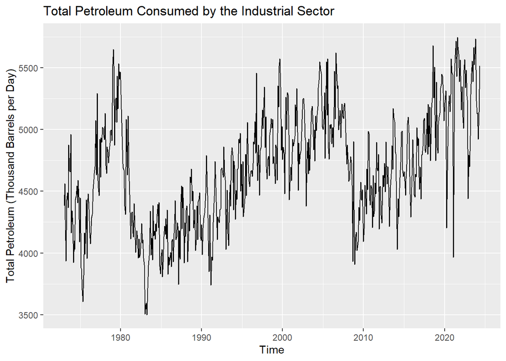

```r
### Autoplot
autoplot(industial_ts)+
  ggtitle("Total Petroleum Consumed by the Industrial Sector") +
  xlab("Time") + ylab("Total Petroleum (Thousand Barrels per Day)")
```

According to Figure above, four non-linear upward trends can be observed during the periods 1975-1980, 1983-2000, 2004-2007, and 2010-2024, as the intervals of the data movement are not constant, which might be cyclical. In terms of seasonality, no clear seasonal patterns are evident, as there are no recurring patterns at fixed intervals.

### 3.2 Seasonal Plot

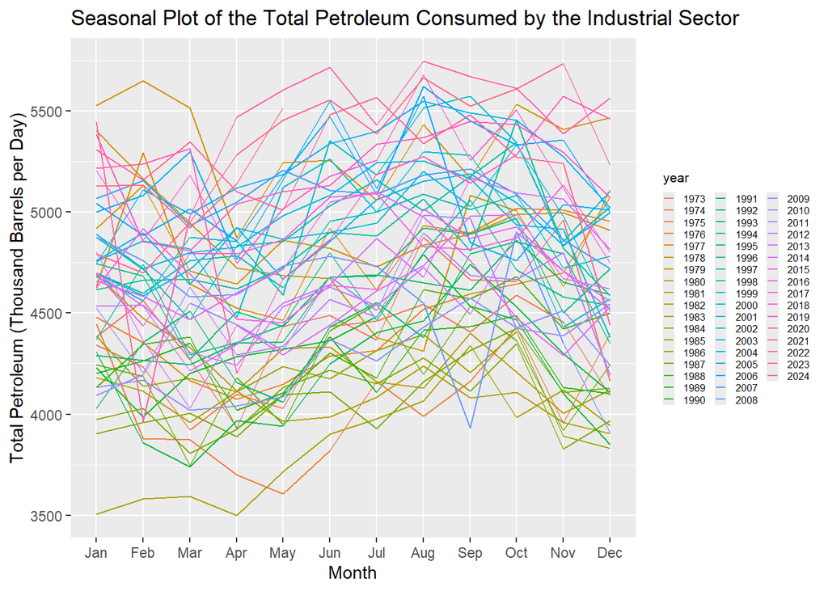

```r
### Seasonal Plot
ggseasonplot(industial_ts) +
  ggtitle("Seasonal Plot of the Total Petroleum Consumed by the Industrial Sector")+
  xlab("Month") + ylab("Total Petroleum (Thousand Barrels per Day)")  +
  theme(
    legend.text = element_text(size = 6),       # Adjusts the legend text size
    legend.title = element_text(size = 8),      # Adjusts the legend title size
    legend.key.size = unit(0.5, "lines")       # Shrinks the legend key box size
  )
```

As observed in the auto plot, we also do not observe the clear seasonality in the monthly seasonal plot above. This suggests that the petroleum consumption in the industrial sector is not influenced by specific seasons or months. It can also be inferred that the industrial sector experiences consistent demand throughout the year, regardless of seasonal factors, likely due to the nature of its projects and operations.

### 3.3 ACF Plot

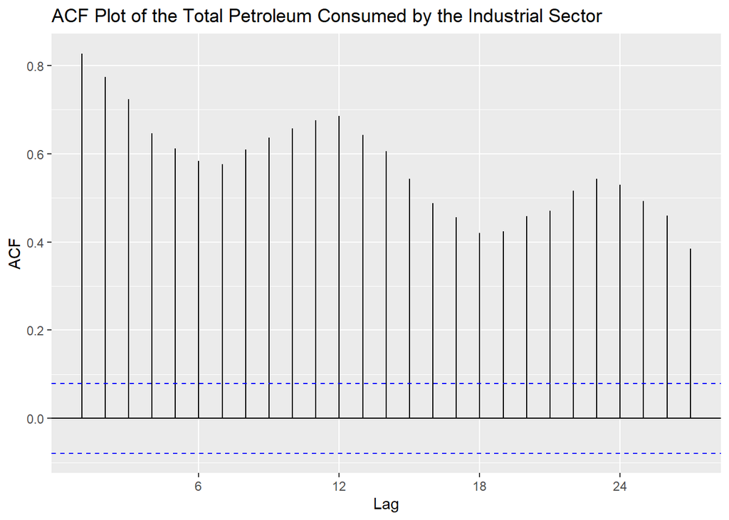

```r
### ggAcf
ggAcf(industial_ts) +
  ggtitle("ACF Plot of the Total Petroleum Consumed by the Industrial Sector")
```

## 4 Data Selection

### 4.1 Modelling Data set

As the current upward trend began in the beginning of 2010, the full data set is defined from January 2010 to December 2019 until the pandemic started.

- **Period**: January 2010 - December 2019
- **Split Portion**: 80:20 (Training : Test set)
- **Training set length**: 96months
- **Test set length**: 24months

```r
# Filter the data to start from 2010 and change the data type to Date
industrial_2010 <- industrial %>%
  filter(Month >= as.Date("2010-01-01"))

# Create time series objects from 2010 onwards
industrial_ts_2010 <- ts(industrial_2010[, -1], start=c(2010,1), frequency=12)

# using precovid data as the Full_Dataset
Full_Dataset_industrial <- window(industrial_ts_2010, end=c(2019,12))


### Industrial Sector
train_industrial <- window(industrial_ts_2010, end = c(2017,12))
test_industrial <- window(industrial_ts_2010, start = c(2018,1), end = c(2019,12))

#check number of observations
length(train_industrial) # 96 (80%)
```

```
[1] 96
```

```r
length(test_industrial) # 24 (20%)
```

```
[1] 24
```

### 4.2 Covid-19 Data Set

The period from 2010 to 2024 was strategically chosen to focus on contemporary trends, particularly the disruptions caused by the COVID-19 pandemic. While previous global events, such as the Japanese asset price bubble, the dot-com bubble, and the subprime mortgage crisis, had profound impacts on economic activity and energy demand, including data from those periods would likely introduce structural breaks unrelated to the COVID-19 crisis. Such breaks could complicate the interpretation of pandemic-specific effects on petroleum consumption. By limiting our analysis to 2010 onwards, we avoid introducing unrelated outliers or breaks from earlier periods, ensuring that the results are more focused on the modern post-COVID energy landscape.

```r
Covid_Period_industrial <- window(industrial_ts_2010, start = c(2020,1), end=c(2024,5))
```

### 4.3 Plot

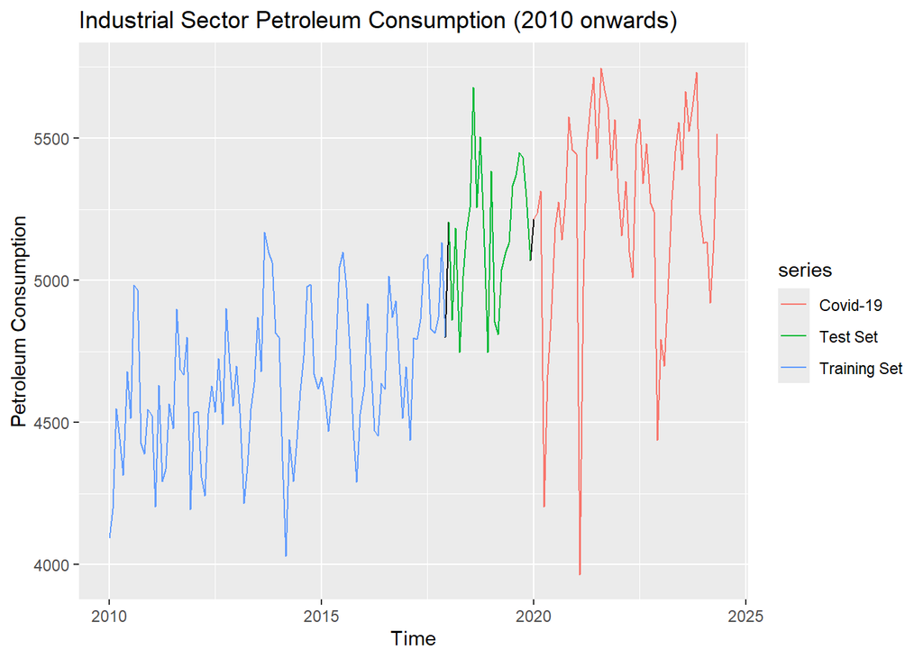

```r
# Visualization for 2010 onwards
autoplot(industrial_ts_2010) +
  autolayer(train_industrial, series = "Training Set") +
  autolayer(test_industrial, series = "Test Set") +
  autolayer(Covid_Period_industrial, series="Covid-19") +
  ggtitle("Industrial Sector Petroleum Consumption (2010 onwards)") +
  ylab("Petroleum Consumption")
```

## 5 Data Preparation

### 5.1 Stationary Process

#### 5.1.1 Box-Cox Transformation

In the above plot, we observe a non-linear upward trend through train and test dataset, however, we are unable to observe a seasonality since this data does not show any particular pattern in a fixed duration. Therefore, we do not consider Box-Cox transformation since the purpose of the transformation is to simplify the patterns in the historical data by removing known sources of variation; however, the patterns are unknown as a clear seasonality does not seems to exist.

```r
## Box-Cox Transformation

#gain the lambdal value for Industrial industry
bc_lambda2<- BoxCox.lambda(train_industrial)
bc_lambda2
```

```
[1] 1.999924
```

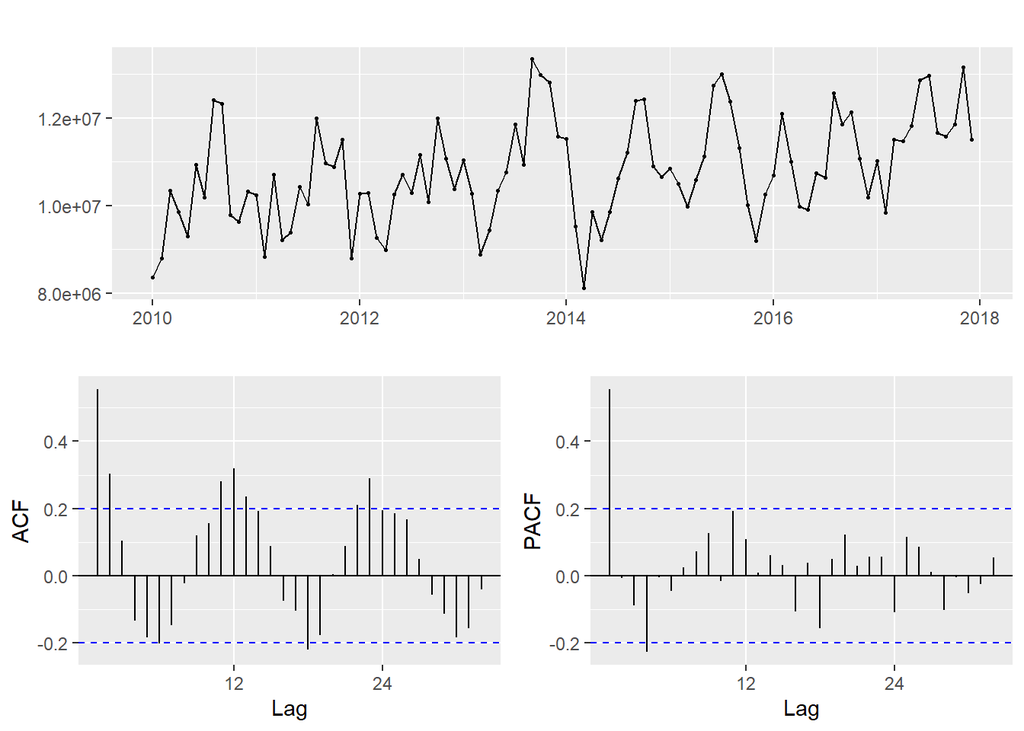

```r
#Do the BC- transformation for Industrial industry
train_industrial %>%  BoxCox(lambda= bc_lambda2) %>% ggtsdisplay()
```

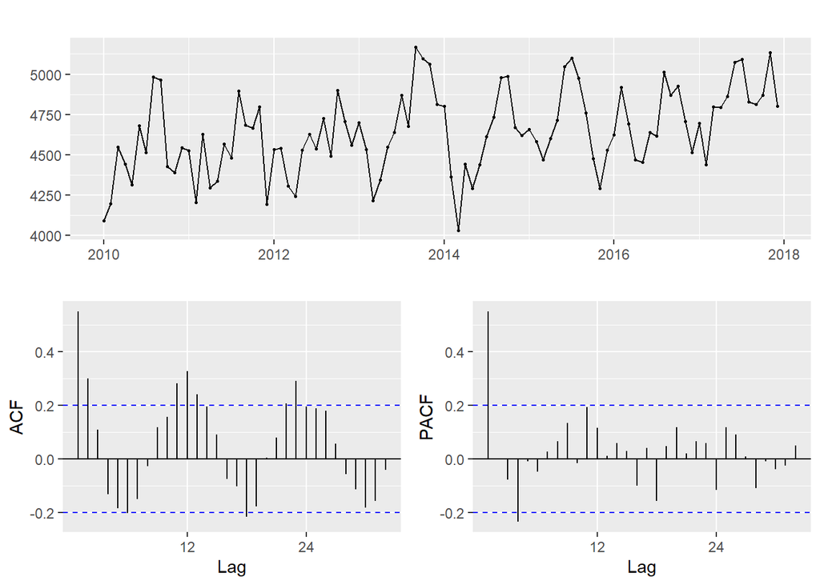

```r
# without BC transformation
train_industrial %>% ggtsdisplay()
```

Initially, we tried applying the Box-Cox transformation using the lambda value generated by R, which was 1.999924. However, after comparing the plots before and after the transformation, we noticed only a slight change in variance. The difference between the two was negligible. As a result, we decided not to use the Box-Cox transformation for variance stabilization. Therefore, we choose to skip the Box-Cox transformation (Hyndman & Athanasopoulos, 2021).

#### 5.1.2 Differencing Process

Next, we focused on stationarity concerning the stability of the mean and patterns. The primary goal of preparing the dataset for ARIMA analysis is to transform the data into a stationary process. This means ensuring that the mean remains constant, the variance is stable, and there are no predictable patterns over time.

```r
## Differencing

#check whether a seasonal difference is needed for industrial industry
train_industrial %>% nsdiffs() # 0: no seasonal differencing is recommended
```

```
[1] 0
```

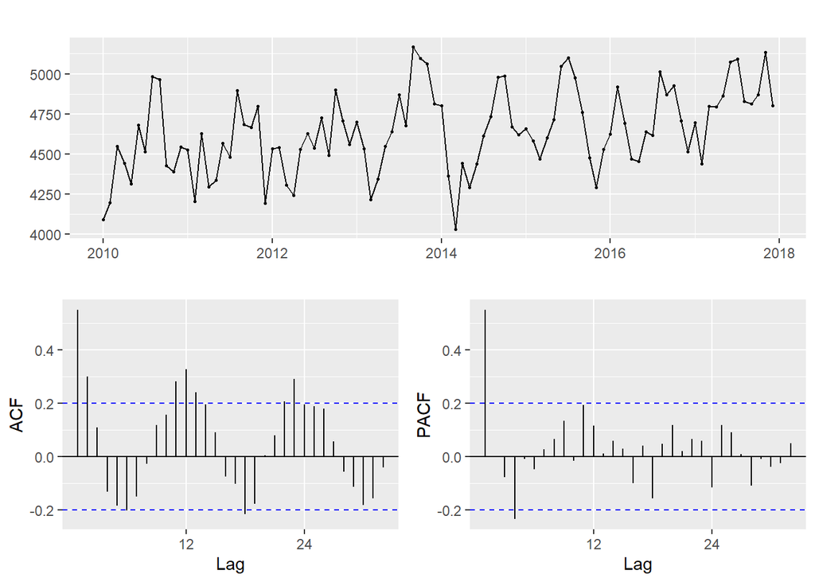

```r
train_industrial %>% ggtsdisplay() # However clear seasonality in ACF and PACF
```

```r
#check whether a first difference is needed
train_industrial %>% diff(lag=12) %>% ndiffs() # Additional lag 0 differencing is recommended
```

```
[1] 0
```

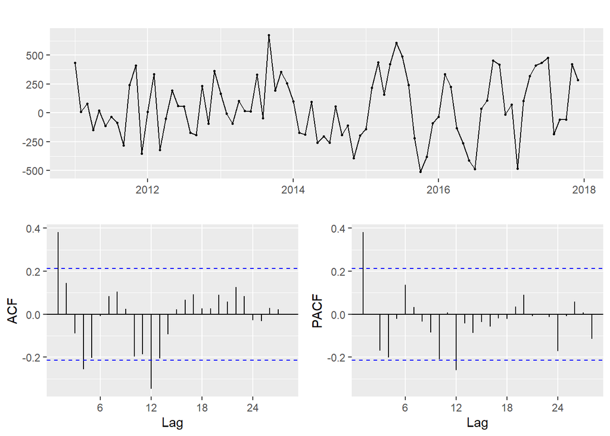

```r
# Result plot
train_industrial %>% diff(lag=12) %>% ggtsdisplay()
```

Finally, after performing seasonal differencing (lag 12), it was confirmed that the mean became stable, the variance remained stable, and no long-term predictable patterns were observed.

At this point, the ndiffs() function was used to check whether additional differencing was required to stabilize the data. The result indicated that no further differencing was necessary, confirming that the data had already reached a stationary state. Therefore, by applying seasonal differencing at lag 12 (D=1) and no need for first-order differencing (d=0), the series became stationary with d=0, D=1, and d+D=1.

## 6 Model Selection

### 6.1 Pure AR Model

```r
# pure AR model(1): ARIMA(1,0,0)(1,1,0)[12]
fit_industrial1 <- Arima(train_industrial, order = c(1,0,0), season = c(1,1,0))
```

#### 6.1.1 Ljung-Box Test

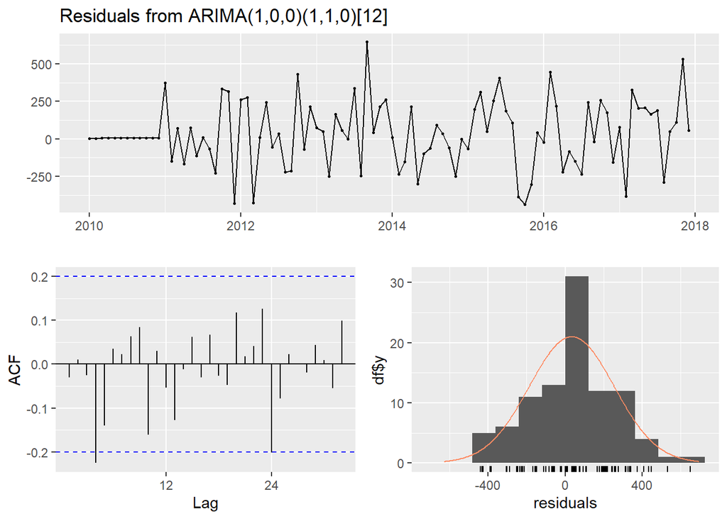

```
    Ljung-Box test

data:  Residuals from ARIMA(1,0,0)(1,1,0)[12]
Q* = 15.338, df = 17, p-value = 0.5711

Model df: 2.   Total lags used: 19
```

```r
# ljung-box test
checkresiduals(fit_industrial1) # ARIMA(1,0,0)(1,1,0)[12]: Pass
```

We will use the checkresiduals() function to verify if the residuals of these models meet the criteria for white noise by ljung-box test.

- H0: There is no autocorrelation in the residuals.
- H1: At least one of the autocorrelations in the residuals up to 19 lags.

For the pure AR model, the mean of the residual appears to be close to zero, and the variance seems to be constant. Additionally, according to the results of the Ljung-Box test, the p-value for fit_industry1 is 0.5711. Since the p-value is more than 0.05, there is insufficient evidence to reject the null hypothesis that there is no autocorrelation in the residuals, indicating that the residuals can be considered white noise. Therefore, re-identification is not necessary for the model.

### 6.2 Pure MA Model

#### 6.2.1 Ljung-Box Test

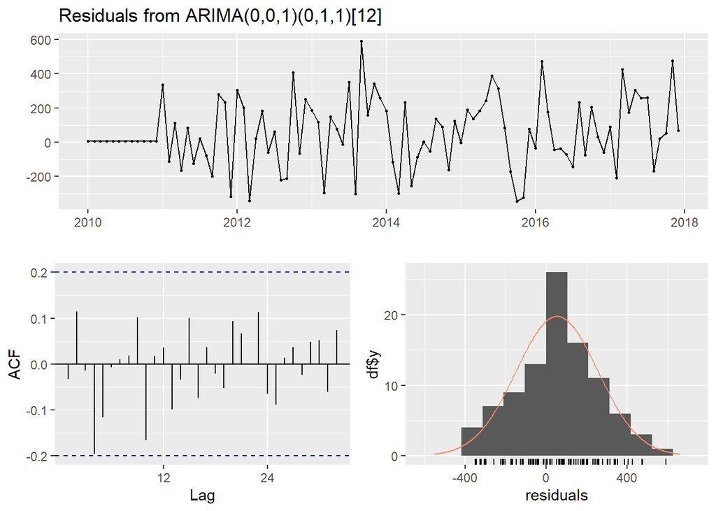

```
    Ljung-Box test

data:  Residuals from ARIMA(0,0,1)(0,1,1)[12]
Q* = 14.78, df = 17, p-value = 0.6113

Model df: 2.   Total lags used: 19
```

```r
# ljung-box test
checkresiduals(fit_industrial2) # ARIMA(0,0,1)(0,1,1)[12]: Pass
```

We will use the checkresiduals() function to verify if the residuals of these models meet the criteria for white noise by ljung-box test.

- H0: There is no autocorrelation in the residuals.
- H1: At least one of the autocorrelations in the residuals up to 19 lags.

For pure MA model, the mean of the residual appears to be close to zero, and the variance seems to be constant. Additionally, according to the results of the Ljung-Box test, the p-value for fit_industry2 is 0.6113. The p-value is more than 0.05, there is insufficient evidence to reject the null hypothesis, indicating that the residuals can be considered white noise, which does not require to reidentify the model.

### 6.3 Auto ARIMA Model

For auto ARIMA model, we used the auto.arima() function to build another ARIMA model. The result suggests ARIMA(1,1,1)(1,0,0)[12], denoted as ‘auto_arima_industrial’.

#### 6.3.1 Ljung-Test

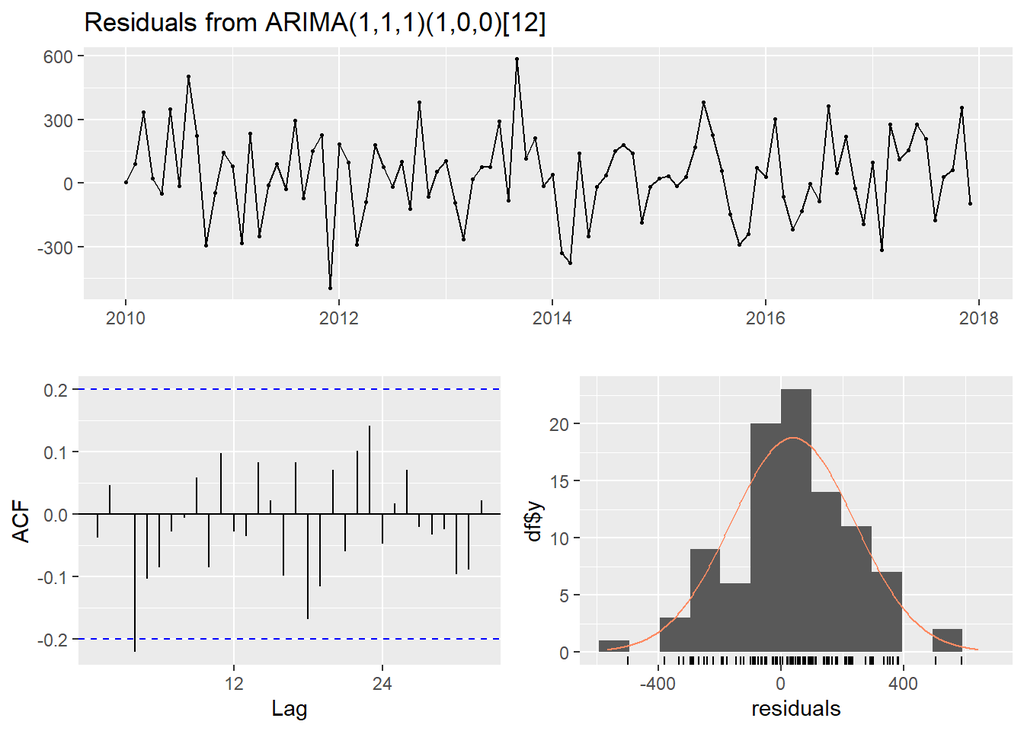

```
    Ljung-Box test

data:  Residuals from ARIMA(1,1,1)(1,0,0)[12]
Q* = 17.596, df = 16, p-value = 0.3481

Model df: 3.   Total lags used: 19
```

```r
# ljung box test
checkresiduals(auto_arima_industrial)
```

The residuals of the ARIMA(1,1,1)(1,0,0)[12] model exhibit a zero mean and constant variance, aligning with some of the assumptions of a well-behaved residual series. The histogram of the residuals shows that they are approximately normally distributed, indicating that the residuals are symmetrically centered around zero without significant skewness or kurtosis. To statistically evaluate the presence of autocorrelation in the residuals, we conducted the following hypothesis test:

H₀: There is no autocorrelation in the residuals.

H₁: At least one of the autocorrelations in the residuals is significant.

### 6.4 Auto ETS Model

```r
## Auto ets model
# develop auto ets model
auto_ets_industrial <- ets(train_industrial) # ETS(M,A,A)

# Check the result
summary(auto_ets_industrial)
```

```
ETS(M,A,A)

Call:
ets(y = train_industrial)

  Smoothing parameters:
    alpha = 5e-04
    beta  = 1e-04
    gamma = 1e-04

  Initial states:
    l = 4482.3407
    b = 3.3537
    s = -100.848 55.7088 152.6431 220.2689 235.5492 59.1909
           56.5035 -121.7612 -193.2253 -173.1783 -137.3123 -53.5393

  sigma:  0.0438

     AIC     AICc      BIC
1475.251 1483.097 1518.845

Training set error measures:
                   ME    RMSE      MAE        MPE     MAPE      MASE      ACF1
Training set -2.46755 186.543 154.9604 -0.2125913 3.346057 0.6882641 0.3167086
```

Next, we used the ets() function in R to automatically select an appropriate ETS model. The result was the ETS(M,A,A) model. Here, “M” indicates multiplicative errors, meaning that forecast errors are proportional to the level of the time series. “A” denotes an additive trend, indicating that a long-term trend is considered in the data. The final “A” indicates additive seasonality. This model is well-suited for capturing the multiplicative nature of errors and the additive trend and seasonality in the data.

#### 6.4.1 Ljung-Box Test

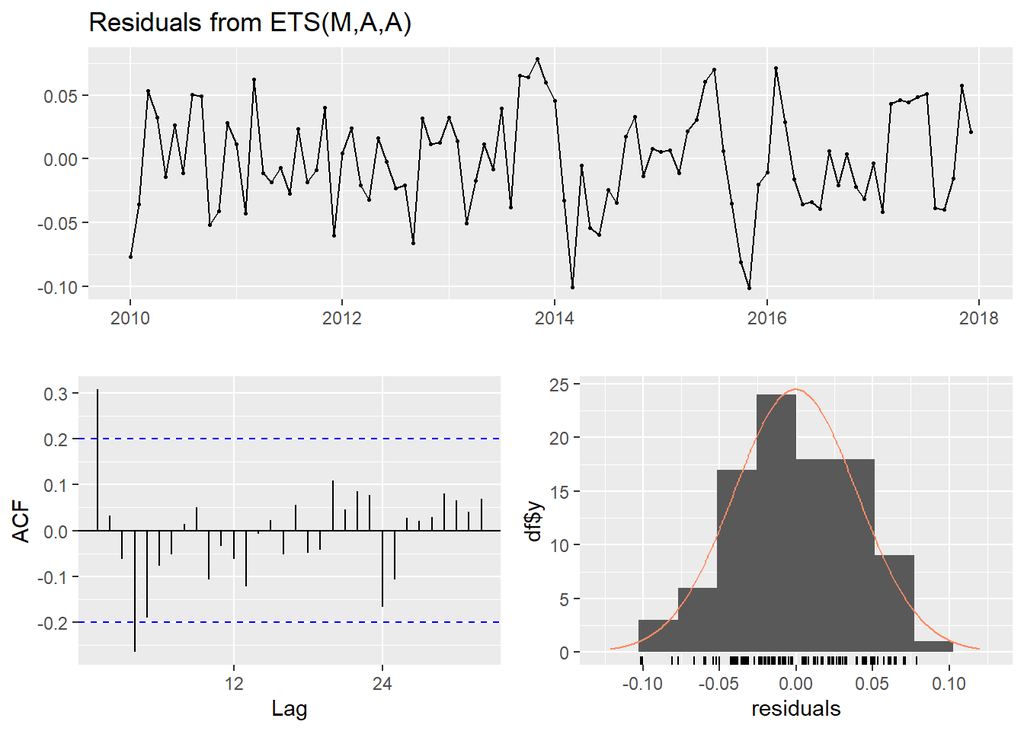

```
    Ljung-Box test

data:  Residuals from ETS(M,A,A)
Q* = 26.639, df = 19, p-value = 0.1134

Model df: 0.   Total lags used: 19
```

```r
# ljunb-box test
checkresiduals(auto_ets_industrial)
```

The residuals of the ETS(M,A,A) model exhibit a zero mean and constant variance, aligning with some of the assumptions of a well-behaved residual series. The histogram of the residuals indicates that they are approximately normally distributed, suggesting that the residuals are symmetrically centered around zero, with no significant skewness or kurtosis. However, spikes are observed at the first and fourth lags in the ACF plot. Next, we performed the following hypothesis test to statistically evaluate the presence of autocorrelation in the residuals:

H₀: There is no autocorrelation in the residuals.

H₁: At least one of the autocorrelations in the residuals is significant up to lag 19

Using the Ljung-Box test, the p-value associated with this test was 0.1134, which is higher than the conventional significance level of α = 0.05. As a result, we could not reject the null hypothesis, meaning that there is no evidence of significant autocorrelation in the residuals up to lag 19.

## 7 Model Evaluation

### 7.1 Forecast Interval

#### 7.1.1 Pure AR vs Pure MA Model

For 𝑑=0 and 𝐷=1 ARIMA models we have, because there is no clear trend for a long-term in the data after differencing based on time series plot in Figure, therefore it is not necessary to retain the constant term. Therefore, at this stage, we estimated two pure ARIMA models using the training dataset for the Industrial sector without including constants. Two forecast model we have now are:

- ARIMA (1,0,0)(1,1,0)[12] without constant, denoted as ’ fit_industry1’
- ARIMA (0,0,1)(0,1,1)[12] without constant, denoted as ’ fit_industry2’

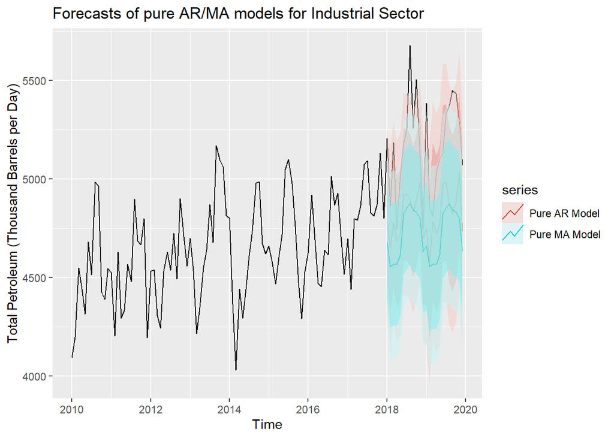

```r
# forecast
fc1_industrial <- forecast(fit_industrial1, h=length(test_industrial)) # AR
fc2_industrial <- forecast(fit_industrial2, h=length(test_industrial)) # MA

# Autoplot
autoplot(Full_Dataset_industrial) +
  autolayer(fc1_industrial, series =  "Pure AR Model",
            alpha = 0.5) +
  autolayer(fc2_industrial, series =  "Pure MA Model",
            alpha = 0.5) +
  ggtitle("Forecasts of pure AR/MA models for Industrial Sector") +
  xlab("Time") + ylab("Total Petroleum (Thousand Barrels per Day)")
```

After the residuals check, we conduct 2 forecasts for test data of the industrial sector by using fc1_Industrial, fc2_Industrial. According to the forecast plot with the actual test data below in figure below, the forecast intervals are all within a reasonable range. Therefore, we proceed to examine the model’s goodness of fit & forecast accuracy.

##### 7.1.1.1 Summary

```r
# summary
summary(fc1_industrial)
```

```
Forecast method: ARIMA(1,0,0)(1,1,0)[12]

Model Information:
Series: train_industrial
ARIMA(1,0,0)(1,1,0)[12]

Coefficients:
         ar1     sar1
      0.3891  -0.3569
s.e.  0.1024   0.1121

sigma^2 = 57674:  log likelihood = -579.5
AIC=1165.01   AICc=1165.31   BIC=1172.3

Error measures:
                   ME    RMSE      MAE       MPE     MAPE      MASE        ACF1
Training set 33.22599 221.954 169.8269 0.5895324 3.643139 0.7542945 -0.03080685

Forecasts:
         Point Forecast    Lo 80    Hi 80    Lo 95    Hi 95
Jan 2018       4779.258 4471.487 5087.029 4308.563 5249.953
Feb 2018       4652.445 4322.193 4982.697 4147.368 5157.522
Mar 2018       4776.570 4443.046 5110.094 4266.489 5286.651
Apr 2018       4684.107 4350.090 5018.124 4173.272 5194.941
May 2018       4719.767 4385.676 5053.859 4208.819 5230.716
Jun 2018       4919.661 4585.559 5253.764 4408.696 5430.627
Jul 2018       4922.806 4588.702 5256.910 4411.838 5433.775
Aug 2018       4895.864 4561.760 5229.969 4384.896 5406.833
Sep 2018       4833.283 4499.178 5167.387 4322.314 5344.251
Oct 2018       4891.257 4557.152 5225.361 4380.288 5402.226
Nov 2018       4981.479 4647.374 5315.584 4470.510 5492.448
Dec 2018       4698.408 4364.304 5032.513 4187.440 5209.377
Jan 2019       4749.500 4361.169 5137.831 4155.598 5343.402
Feb 2019       4576.087 4180.191 4971.983 3970.617 5181.557
Mar 2019       4784.091 4387.063 5181.120 4176.888 5391.294
Apr 2019       4722.857 4325.657 5120.057 4115.392 5330.321
May 2019       4771.117 4373.891 5168.342 4163.612 5378.621
Jun 2019       4974.846 4577.616 5372.075 4367.336 5582.356
Jul 2019       4983.437 4586.207 5380.667 4375.926 5590.948
Aug 2019       4872.239 4475.009 5269.470 4264.728 5479.751
Sep 2019       4826.179 4428.949 5223.409 4218.668 5433.690
Oct 2019       4884.017 4486.787 5281.248 4276.506 5491.529
Nov 2019       5035.522 4638.291 5432.752 4428.010 5643.033
Dec 2019       4734.690 4337.460 5131.920 4127.179 5342.201
```

```r
summary(fc2_industrial)
```

```
Forecast method: ARIMA(0,0,1)(0,1,1)[12]

Model Information:
Series: train_industrial
ARIMA(0,0,1)(0,1,1)[12]

Coefficients:
         ma1     sma1
      0.3888  -0.6678
s.e.  0.0986   0.1618

sigma^2 = 51053:  log likelihood = -577.1
AIC=1160.2   AICc=1160.5   BIC=1167.49

Error measures:
                   ME     RMSE     MAE      MPE     MAPE      MASE        ACF1
Training set 53.97469 208.8253 162.714 1.030037 3.475568 0.7227021 -0.03326999

Forecasts:
         Point Forecast    Lo 80    Hi 80    Lo 95    Hi 95
Jan 2018       4677.180 4387.468 4966.892 4234.104 5120.256
Feb 2018       4554.866 4244.046 4865.686 4079.507 5030.224
Mar 2018       4566.739 4255.919 4877.559 4091.380 5042.097
Apr 2018       4566.831 4256.011 4877.651 4091.472 5042.189
May 2018       4615.104 4304.284 4925.924 4139.745 5090.462
Jun 2018       4823.460 4512.640 5134.280 4348.102 5298.819
Jul 2018       4852.433 4541.613 5163.253 4377.074 5327.791
Aug 2018       4875.338 4564.517 5186.158 4399.979 5350.696
Sep 2018       4843.729 4532.909 5154.549 4368.371 5319.087
Oct 2018       4830.795 4519.975 5141.615 4355.437 5306.154
Nov 2018       4801.344 4490.523 5112.164 4325.985 5276.702
Dec 2018       4631.361 4320.551 4942.172 4156.018 5106.705
Jan 2019       4659.661 4334.301 4985.020 4162.066 5157.255
Feb 2019       4554.866 4227.356 4882.376 4053.982 5055.749
Mar 2019       4566.739 4239.229 4894.249 4065.855 5067.622
Apr 2019       4566.831 4239.321 4894.341 4065.947 5067.714
May 2019       4615.104 4287.594 4942.614 4114.220 5115.987
Jun 2019       4823.460 4495.950 5150.970 4322.577 5324.344
Jul 2019       4852.433 4524.923 5179.943 4351.549 5353.316
Aug 2019       4875.338 4547.827 5202.848 4374.454 5376.221
Sep 2019       4843.729 4516.219 5171.239 4342.845 5344.612
Oct 2019       4830.795 4503.285 5158.305 4329.912 5331.679
Nov 2019       4801.344 4473.834 5128.854 4300.460 5302.227
Dec 2019       4631.361 4303.860 4958.862 4130.492 5132.230
```

#### 7.1.2 Auto ETS vs Auto ARIMA Model

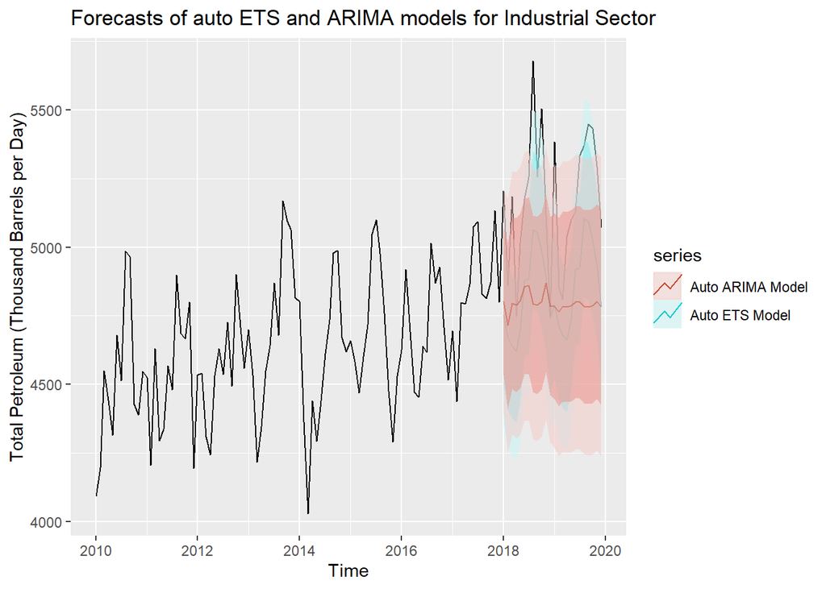

```r
# forecast
fc_ets_industrial <- forecast(auto_ets_industrial, h = length(test_industrial))
fc_arima_industrial <- forecast(auto_arima_industrial, h=length(test_industrial))

# Autoplot
autoplot(Full_Dataset_industrial) +
  autolayer(fc_ets_industrial, series =  "Auto ETS Model",
            alpha = 0.5) +
  autolayer(fc_arima_industrial, series =  "Auto ARIMA Model",
            alpha = 0.5) +
  ggtitle("Forecasts of auto ETS and ARIMA models for Industrial Sector") +
  xlab("Time") + ylab("Total Petroleum (Thousand Barrels per Day)")
```

We conduct 2 forecasts for test data of the industrial sector by using the auto ETS and auto ARIMA models. According to the forecast plot with the actual test data below in figure, the forecast intervals are all within a reasonable range. Therefore, we proceed to examine the model’s goodness of fit & forecast accuracy.

##### 7.1.2.1 Summary

```r
summary(fc_ets_industrial)
```

```
Forecast method: ETS(M,A,A)

Model Information:
ETS(M,A,A)

Call:
ets(y = train_industrial)

  Smoothing parameters:
    alpha = 5e-04
    beta  = 1e-04
    gamma = 1e-04

  Initial states:
    l = 4482.3407
    b = 3.3537
    s = -100.848 55.7088 152.6431 220.2689 235.5492 59.1909
           56.5035 -121.7612 -193.2253 -173.1783 -137.3123 -53.5393

  sigma:  0.0438

     AIC     AICc      BIC
1475.251 1483.097 1518.845

Error measures:
                   ME    RMSE      MAE        MPE     MAPE      MASE      ACF1
Training set -2.46755 186.543 154.9604 -0.2125913 3.346057 0.6882641 0.3167086

Forecasts:
         Point Forecast    Lo 80    Hi 80    Lo 95    Hi 95
Jan 2018       4751.647 4484.664 5018.631 4343.332 5159.963
Feb 2018       4671.183 4408.721 4933.645 4269.781 5072.584
Mar 2018       4638.664 4378.029 4899.300 4240.058 5037.271
Apr 2018       4621.955 4362.259 4881.652 4224.784 5019.126
May 2018       4696.731 4432.834 4960.629 4293.135 5100.328
Jun 2018       4878.348 4604.245 5152.450 4459.144 5297.551
Jul 2018       4884.371 4609.930 5158.812 4464.649 5304.092
Aug 2018       5064.015 4779.480 5348.550 4628.857 5499.174
Sep 2018       5052.064 4768.200 5335.928 4617.932 5486.196
Oct 2018       4987.781 4707.529 5268.034 4559.173 5416.390
Nov 2018       4894.194 4619.200 5169.188 4473.627 5314.761
Dec 2018       4740.972 4474.587 5007.357 4333.571 5148.373
Jan 2019       4791.607 4522.376 5060.837 4379.854 5203.359
Feb 2019       4711.142 4446.432 4975.852 4306.303 5115.981
Mar 2019       4678.624 4415.741 4941.507 4276.579 5080.669
Apr 2019       4661.915 4399.970 4923.860 4261.304 5062.525
May 2019       4736.691 4470.544 5002.838 4329.654 5143.728
Jun 2019       4918.307 4641.955 5194.659 4495.663 5340.951
Jul 2019       4924.330 4647.639 5201.021 4501.168 5347.493
Aug 2019       5103.975 4817.189 5390.760 4665.374 5542.575
Sep 2019       5092.023 4805.909 5378.138 4654.449 5529.598
Oct 2019       5027.741 4745.237 5310.245 4595.689 5459.793
Nov 2019       4934.154 4656.907 5211.400 4510.142 5358.165
Dec 2019       4780.931 4512.292 5049.570 4370.084 5191.778
```

```r
summary(fc_arima_industrial)
```

```
Forecast method: ARIMA(1,1,1)(1,0,0)[12]

Model Information:
Series: train_industrial
ARIMA(1,1,1)(1,0,0)[12]

Coefficients:
         ar1      ma1    sar1
      0.4899  -0.9576  0.2546
s.e.  0.1000   0.0301  0.1097

sigma^2 = 43345:  log likelihood = -641.42
AIC=1290.83   AICc=1291.28   BIC=1301.05

Error measures:
                   ME     RMSE      MAE       MPE     MAPE      MASE
Training set 38.84992 203.8108 159.2547 0.6726174 3.417933 0.7073376
                    ACF1
Training set -0.03794146

Forecasts:
         Point Forecast    Lo 80    Hi 80    Lo 95    Hi 95
Jan 2018       4801.389 4534.576 5068.202 4393.334 5209.444
Feb 2018       4713.968 4411.703 5016.232 4251.694 5176.241
Mar 2018       4794.694 4481.789 5107.599 4316.147 5273.241
Apr 2018       4788.176 4471.150 5105.203 4303.326 5273.027
May 2018       4803.672 4484.576 5122.768 4315.656 5291.687
Jun 2018       4856.046 4535.627 5176.466 4366.007 5346.086
Jul 2018       4860.115 4538.677 5181.553 4368.518 5351.713
Aug 2018       4792.841 4470.520 5115.163 4299.893 5285.789
Sep 2018       4788.545 4465.404 5111.686 4294.343 5282.746
Oct 2018       4803.137 4479.208 5127.066 4307.730 5298.544
Nov 2018       4869.796 4545.094 5194.497 4373.208 5366.384
Dec 2018       4785.028 4459.563 5110.493 4287.272 5282.784
Jan 2019       4785.357 4447.631 5123.084 4268.849 5301.865
Feb 2019       4763.093 4420.358 5105.828 4238.925 5287.261
Mar 2019       4783.646 4438.249 5129.043 4255.407 5311.885
Apr 2019       4781.986 4434.803 5129.168 4251.016 5312.956
May 2019       4785.931 4437.329 5134.533 4252.790 5319.072
Jun 2019       4799.267 4449.411 5149.123 4264.208 5334.326
Jul 2019       4800.303 4449.271 5151.334 4263.447 5337.159
Aug 2019       4783.173 4431.006 5135.340 4244.580 5321.765
Sep 2019       4782.079 4428.797 5135.360 4241.781 5322.376
Oct 2019       4785.794 4431.410 5140.179 4243.810 5327.779
Nov 2019       4802.768 4447.288 5158.248 4259.108 5346.427
Dec 2019       4781.183 4424.613 5137.753 4235.856 5326.510
```